# Tabla resumen: Descubrimiento, Validacion y Consistencia

TFM Melanoma Inmunoterapia

2026-05-18

# 1 Objetivo

Este informe consolida los resultados de los bloques de descubrimiento (01), validacion tumoral NanoString (02), validacion externa/sensibilidad periferica (03) y consistencia integrada (04) en tablas y figuras resumidas para revision.

# 2 Librerias

# 3 Rutas y carga de resultados

# 4 Resumen de cohortes

Tabla 1. Resumen de cohortes analizadas

| Bloque | Dataset | Tejido | Plataforma | Tratamiento | N_muestras | N_respondedores | N_no_respondedores |
| --- | --- | --- | --- | --- | --- | --- | --- |
| Descubrimiento | GSE78220 | Tumor | RNA-seq | anti-PD-1 | 25 | 14 | 11 |
| Validacion 1 | GSE215868 | Tumor | NanoString | anti-PD-1 | 105 | 45 | 59 |
| Validacion 2 | GSE211645 | Tumor | NanoString | anti-CTLA-4 | 40 | 12 | 28 |
| Validacion 3 | GSE91061 | Tumor | RNA-seq | anti-PD-1 | 51 | 10 | 39 |
| Sensibilidad | GSE94873 | Sangre | NanoString | anti-CTLA-4 | 360 | 46 | 314 |

# 5 Descubrimiento: GSE78220

## 5.1 Top genes por expresion diferencial

Tabla 2. Top 20 genes DEA en GSE78220 (n=25; ordenados por P nominal)

| Gen | logFC | P.Value | adj.P.Val | Direccion |
| --- | --- | --- | --- | --- |
| ALDH1L2 | -1.282 | 0.000128 | 0.764 | Down en respondedores |
| MFAP2 | -2.901 | 0.000134 | 0.764 | Down en respondedores |
| CDH1 | 3.302 | 0.000157 | 0.764 | Up en respondedores |
| MAP2K5 | 0.762 | 0.000238 | 0.867 | Up en respondedores |
| FBLN2 | -1.818 | 0.000373 | 0.999 | Down en respondedores |
| H1F0 | -1.618 | 0.000425 | 0.999 | Down en respondedores |
| TRAF3IP2 | 1.196 | 0.000607 | 0.999 | Up en respondedores |
| OLIG1 | 1.987 | 0.000872 | 0.999 | Up en respondedores |
| FBLN1 | -2.429 | 0.000895 | 0.999 | Down en respondedores |
| SLC16A3 | -1.847 | 0.001130 | 0.999 | Down en respondedores |
| ANO1 | -1.197 | 0.001170 | 0.999 | Down en respondedores |
| MXRA8 | -1.924 | 0.001300 | 0.999 | Down en respondedores |
| CILP2 | -0.945 | 0.001320 | 0.999 | Down en respondedores |
| RASL12 | -1.105 | 0.001400 | 0.999 | Down en respondedores |
| AXL | -1.409 | 0.001500 | 0.999 | Down en respondedores |
| TIMP3 | -1.477 | 0.001650 | 0.999 | Down en respondedores |
| PDGFRB | -1.277 | 0.001780 | 0.999 | Down en respondedores |
| JMJD7 | 0.914 | 0.001790 | 0.999 | Up en respondedores |
| MIR503HG | -0.883 | 0.001810 | 0.999 | Down en respondedores |
| COL6A3 | -1.697 | 0.001930 | 0.999 | Down en respondedores |

```
## Genes nominalmente significativos (P<0.05, |logFC|>=0.5): 539  |  Significativos FDR (adj.P<0.05): 0
```

```
## Nota: con n=25 no se alcanzan genes significativos por FDR; los resultados de descubrimiento son hipotesis nominales.
```

## 5.2 Preprocesado y control de calidad

Tabla 2b. Control de calidad y filtrado aplicado a GSE78220

| paso | valor |
| --- | --- |
| Genes/filas originales | 25268 |
| Simbolos duplicados colapsados | 0 |
| Genes tras colapsar simbolos | 25268 |
| Genes retirados por NA | 0 |
| Genes retirados por varianza cero | 2663 |
| Genes retirados por baja expresion (FPKM < 1 en al menos 5 muestras) | 10719 |
| Genes retenidos para DEA | 14549 |

## 5.3 Enriquecimiento funcional exploratorio

Tabla 2c. Top terminos GO BP del enriquecimiento exploratorio en genes nominales

| Direccion | Termino_GO | GeneRatio | Count | pvalue | FDR |
| --- | --- | --- | --- | --- | --- |
| Down en respondedores | extracellular matrix organization | 44/290 | 44 | 0.00e+00 | 0.00e+00 |
| Down en respondedores | extracellular structure organization | 44/290 | 44 | 0.00e+00 | 0.00e+00 |
| Down en respondedores | external encapsulating structure organization | 44/290 | 44 | 0.00e+00 | 0.00e+00 |
| Down en respondedores | angiogenesis | 43/290 | 43 | 0.00e+00 | 0.00e+00 |
| Down en respondedores | collagen fibril organization | 15/290 | 15 | 0.00e+00 | 0.00e+00 |
| Down en respondedores | regulation of cellular response to growth factor stimulus | 27/290 | 27 | 0.00e+00 | 1.00e-07 |
| Down en respondedores | cell-substrate adhesion | 29/290 | 29 | 0.00e+00 | 1.00e-07 |
| Down en respondedores | ossification | 31/290 | 31 | 0.00e+00 | 1.00e-07 |
| Up en respondedores | amino acid catabolic process | 8/169 | 8 | 1.81e-05 | 3.26e-02 |
| Up en respondedores | alpha-amino acid catabolic process | 7/169 | 7 | 4.61e-05 | 3.26e-02 |
| Up en respondedores | respiratory electron transport chain | 8/169 | 8 | 6.33e-05 | 3.26e-02 |
| Up en respondedores | cytoplasmic translation | 10/169 | 10 | 7.65e-05 | 3.26e-02 |
| Up en respondedores | organophosphate biosynthetic process | 19/169 | 19 | 8.12e-05 | 3.26e-02 |
| Up en respondedores | aerobic electron transport chain | 7/169 | 7 | 8.77e-05 | 3.26e-02 |
| Up en respondedores | electron transport chain | 8/169 | 8 | 1.12e-04 | 3.47e-02 |
| Up en respondedores | amino acid metabolic process | 11/169 | 11 | 1.29e-04 | 3.47e-02 |

## 5.4 Modelo exploratorio LOOCV

Tabla 3. Modelo exploratorio LOOCV en GSE78220 (firma de descubrimiento interna)

| N genes firma | AUC | Accuracy |
| --- | --- | --- |
| 5 | 0.853 | 0.76 |
| 10 | 0.686 | 0.60 |
| 50 | 0.571 | 0.60 |
| 20 | 0.558 | 0.44 |

# 6 Validacion tumoral

## 6.1 Resumen global de validacion

Tabla 4. Resumen de validacion tumoral (firma derivada de GSE78220)

| Dataset | Genes | Muestras | No_respondedores | Respondedores | NA_respuesta | Genes solapados (top50) | % misma direccion | AUC firma discovery |
| --- | --- | --- | --- | --- | --- | --- | --- | --- |
| GSE215868 | 770 | 105 | 59 | 45 | 1 | 6 | 66.7 | 0.547 |
| GSE211645 | 418 | 40 | 28 | 12 | 0 | 1 | 0.0 | 0.390 |

## 6.2 Genes de discovery solapados en GSE215868

Tabla 5. Genes del top 50 de discovery presentes en el panel GSE215868

| Gen | logFC discovery | P discovery | logFC GSE215868 | P GSE215868 | Misma direccion |
| --- | --- | --- | --- | --- | --- |
| COL6A3 | -1.697 | 0.001930 | -0.414 | 0.0964 | Si |
| PDGFRB | -1.277 | 0.001780 | -0.234 | 0.1630 | Si |
| ROR2 | -0.939 | 0.002810 | -0.177 | 0.4220 | Si |
| CDH1 | 3.302 | 0.000157 | 0.397 | 0.4250 | Si |
| AXL | -1.409 | 0.001500 | 0.154 | 0.4580 | No |
| BCAT1 | -1.180 | 0.003750 | 0.156 | 0.4960 | No |

## 6.3 Scores de firma: boxplots de validacion

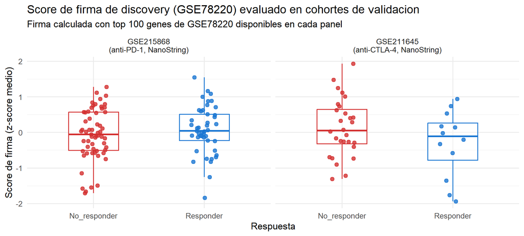

# 7 Validacion tumoral RNA-seq independiente: GSE91061

Tabla 6. Validacion tumoral RNA-seq independiente en GSE91061

| Dataset | Tejido | Plataforma | Tratamiento | Genes | Muestras | Muestras con respuesta | Respondedores | No_respondedores | Top N firma | Genes firma solapados | AUC firma discovery | Interpretacion |
| --- | --- | --- | --- | --- | --- | --- | --- | --- | --- | --- | --- | --- |
| GSE91061 | Tumor | RNA-seq | NA | 22069 | 51 | 49 | 10 | 39 | 20 | 19 | 0.474 | Validacion tumoral RNA-seq independiente; resultado exploratorio |

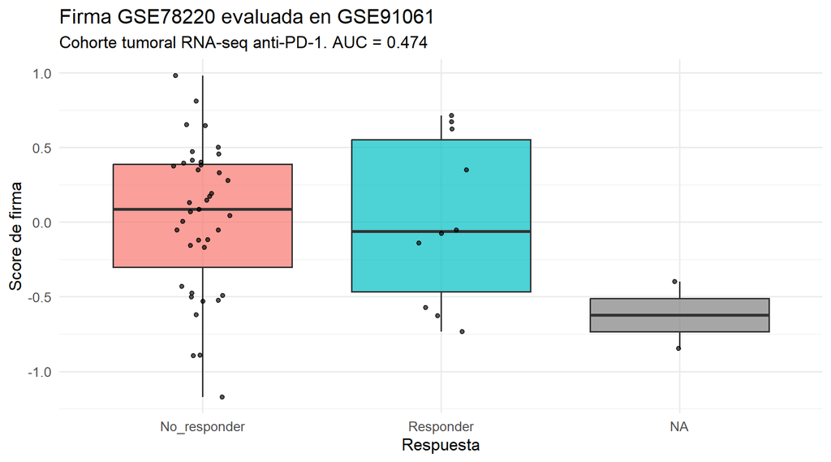

# 8 Sensibilidad en sangre: GSE94873

Tabla 7. Sensibilidad de la firma tumoral evaluada en sangre periferica

| Dataset | Tejido | Plataforma | Tratamiento | Genes | Muestras | Respondedores | No_respondedores | Top N firma | Genes firma solapados | AUC firma discovery | Interpretacion |
| --- | --- | --- | --- | --- | --- | --- | --- | --- | --- | --- | --- |
| GSE94873 | Blood | NanoString | Tremelimumab (anti-CTLA-4) | 169 | 360 | 46 | 314 | 500 | 4 | 0.475 | Sensibilidad periferica: sangre NanoString, anti-CTLA-4 |

## 8.1 Distancia metodologica respecto al discovery

La senal baja en sangre es esperada y se interpreta desde el diseno del estudio. `GSE94873` acumula tres fuentes de distancia respecto a la cohorte de discovery:

Tabla 7b. Distancia metodologica entre GSE94873 y el discovery (GSE78220)

| Factor de distancia | GSE94873 |
| --- | --- |
| Tejido (tumor -> sangre periferica) | Si |
| Checkpoint distinto (anti-PD-1 -> anti-CTLA-4) | Si |
| Plataforma distinta (RNA-seq -> NanoString) | Si |
| N factores de distancia acumulados | 3 |

La ausencia de senal clara en `GSE94873` no se interpreta como fallo de la firma, sino como evidencia de que su transferibilidad a sangre periferica y a otro checkpoint es limitada. `GSE91061` queda fuera de esta tabla porque no es sangre, sino una validacion tumoral RNA-seq independiente.

# 9 Consistencia multi-cohorte

## 9.1 Concordancia global

Tabla 7. Concordancia de direccion de efecto en los 200 genes comunes (3 cohortes tumorales)

| Concordancia | N_genes | % |
| --- | --- | --- |
| Up en todas | 61 | 30.5 |
| Down en todas | 8 | 4.0 |
| Discordante | 131 | 65.5 |

## 9.2 Genes concordantes en las 3 cohortes

Tabla 8. Los 69 genes concordantes en las 3 cohortes (de 200 genes comunes)

Gen

Concordancia

logFC GSE78220

P GSE78220

logFC GSE215868

P GSE215868

logFC GSE211645

P GSE211645

En discovery

VCAN

Down en todas

-1.789

0.00856

-0.363

0.12300

-0.017

9.71e-01

Top100

VCAM1

Down en todas

-0.614

0.22800

-0.037

0.87600

-0.216

5.61e-01

GNG4

Down en todas

-0.531

0.25200

-0.060

0.76000

-0.277

6.23e-01

CXCL14

Down en todas

-0.529

0.56500

-0.387

0.45000

-0.349

6.90e-01

CDH5

Down en todas

-0.446

0.16600

-0.056

0.77300

-0.387

2.76e-01

CD276

Down en todas

-0.372

0.28500

-0.120

0.39600

-0.087

7.56e-01

TLK2

Down en todas

-0.042

0.84100

-0.071

0.42700

-0.144

4.72e-01

ITGB3

Down en todas

-0.009

0.99200

-0.359

0.28700

-2.059

6.34e-04

HLA-A

Up en todas

1.062

0.25900

0.187

0.60700

1.564

9.81e-05

CTAG1B

Up en todas

0.934

0.21500

0.055

0.93300

0.009

9.91e-01

HLA-C

Up en todas

0.878

0.17900

0.594

0.02020

1.235

7.27e-03

HLA-B

Up en todas

0.636

0.32000

0.667

0.00450

1.216

6.92e-03

HLA-DQA1

Up en todas

0.625

0.45200

1.149

0.16500

2.573

4.60e-05

TCL1A

Up en todas

0.595

0.30400

0.182

0.58600

1.004

1.08e-01

SLAMF7

Up en todas

0.538

0.40700

0.468

0.10700

1.392

5.43e-03

HLA-DRB1

Up en todas

0.474

0.66900

0.502

0.07860

1.700

1.21e-03

HLA-F

Up en todas

0.473

0.35700

0.633

0.00820

1.620

7.38e-05

HLA-E

Up en todas

0.450

0.25900

0.336

0.06630

1.428

2.29e-04

G6PD

Up en todas

0.446

0.25800

0.112

0.24100

0.437

1.49e-01

IL6R

Up en todas

0.433

0.22900

0.157

0.34500

0.372

2.38e-01

PSMB8

Up en todas

0.420

0.23800

0.613

0.00194

0.527

5.51e-02

ICAM1

Up en todas

0.356

0.35400

0.271

0.16500

0.725

4.24e-02

STAT3

Up en todas

0.323

0.27700

0.011

0.91100

0.301

1.81e-01

IFNGR1

Up en todas

0.322

0.38900

0.030

0.81700

0.503

5.26e-02

TNFAIP3

Up en todas

0.318

0.44100

0.097

0.67900

0.953

4.35e-03

SELL

Up en todas

0.314

0.55400

0.188

0.46200

0.848

2.97e-02

CD69

Up en todas

0.283

0.61800

0.094

0.71400

0.803

1.10e-01

CCL19

Up en todas

0.276

0.77400

0.101

0.80600

1.579

2.66e-02

PSMB10

Up en todas

0.238

0.59400

0.486

0.00599

0.946

1.98e-02

TAP2

Up en todas

0.236

0.42500

0.419

0.01520

0.761

1.65e-02

CD74

Up en todas

0.227

0.67000

0.481

0.05230

2.160

1.34e-04

B2M

Up en todas

0.222

0.58200

0.537

0.00639

0.845

1.22e-02

PSMB9

Up en todas

0.221

0.62300

0.682

0.00406

1.131

3.24e-03

IL18

Up en todas

0.220

0.70200

0.172

0.49500

0.721

1.05e-01

STAT2

Up en todas

0.219

0.38900

0.159

0.21500

0.294

1.70e-01

APOE

Up en todas

0.199

0.78800

0.105

0.68400

0.544

2.62e-01

HLA-DPA1

Up en todas

0.194

0.68600

0.373

0.13700

2.099

3.88e-05

GNLY

Up en todas

0.185

0.72400

0.546

0.06830

0.386

4.74e-01

TAP1

Up en todas

0.181

0.63500

0.652

0.00537

0.537

3.66e-01

JAK2

Up en todas

0.172

0.62100

0.032

0.82700

0.342

1.64e-01

ITGAX

Up en todas

0.162

0.65400

0.368

0.04650

2.056

9.30e-04

HDAC3

Up en todas

0.155

0.41100

0.133

0.10600

0.499

2.64e-02

TLR9

Up en todas

0.125

0.67700

0.153

0.41000

0.298

6.11e-01

IRF8

Up en todas

0.119

0.83600

0.232

0.32900

1.744

9.06e-05

IL15

Up en todas

0.119

0.73100

0.170

0.42100

1.041

2.92e-02

EOMES

Up en todas

0.112

0.78400

0.369

0.09960

1.532

1.01e-02

CD274

Up en todas

0.109

0.79400

0.625

0.01130

1.768

8.13e-04

CXCL13

Up en todas

0.108

0.90300

0.714

0.02030

1.812

5.59e-02

IRF2

Up en todas

0.105

0.67300

0.108

0.30300

0.690

2.02e-02

ENTPD1

Up en todas

0.104

0.75300

0.014

0.93200

0.641

4.53e-02

NLRC5

Up en todas

0.100

0.75700

0.511

0.02090

1.044

2.12e-03

CD5

Up en todas

0.096

0.80900

0.318

0.12000

1.863

2.34e-03

CXCR4

Up en todas

0.093

0.86400

0.101

0.68500

2.108

1.39e-04

BTLA

Up en todas

0.084

0.78800

0.127

0.65700

1.255

9.07e-03

IL32

Up en todas

0.081

0.89900

0.277

0.24000

1.908

2.77e-04

LCK

Up en todas

0.080

0.88500

0.380

0.15900

1.651

2.05e-03

ICOS

Up en todas

0.038

0.91200

0.281

0.22800

1.609

1.27e-03

CD40

Up en todas

0.028

0.95200

0.255

0.16700

1.093

5.43e-03

DNAJC14

Up en todas

0.026

0.87500

0.028

0.79300

0.334

7.39e-02

FOXP3

Up en todas

0.024

0.94400

0.170

0.40000

0.846

2.02e-01

LY9

Up en todas

0.023

0.95600

0.113

0.68800

2.372

7.90e-05

CSF2

Up en todas

0.023

0.89500

0.258

0.25300

2.156

3.84e-03

IFNGR2

Up en todas

0.020

0.95000

0.020

0.86200

0.581

3.16e-02

CD27

Up en todas

0.014

0.98200

0.297

0.32700

2.357

2.36e-04

OAS2

Up en todas

0.008

0.98500

0.323

0.23100

0.080

8.31e-01

TNF

Up en todas

0.006

0.96400

0.249

0.27100

1.152

2.12e-02

CXCL16

Up en todas

0.004

0.99100

0.160

0.37600

1.420

7.40e-03

IL2RG

Up en todas

0.003

0.99600

0.437

0.11000

1.739

4.51e-04

IL1A

Up en todas

0.003

0.99200

0.233

0.36000

0.572

4.24e-01

## 9.3 Firma biologica clave: IFN-gamma / presentacion de antigeno

Tabla 9. Firma biologica de interes: IFN-gamma / presentacion de antigeno / inmunosupresion

[output not shown]

## 9.4 Visualizacion: logFC de la firma biologica por cohorte

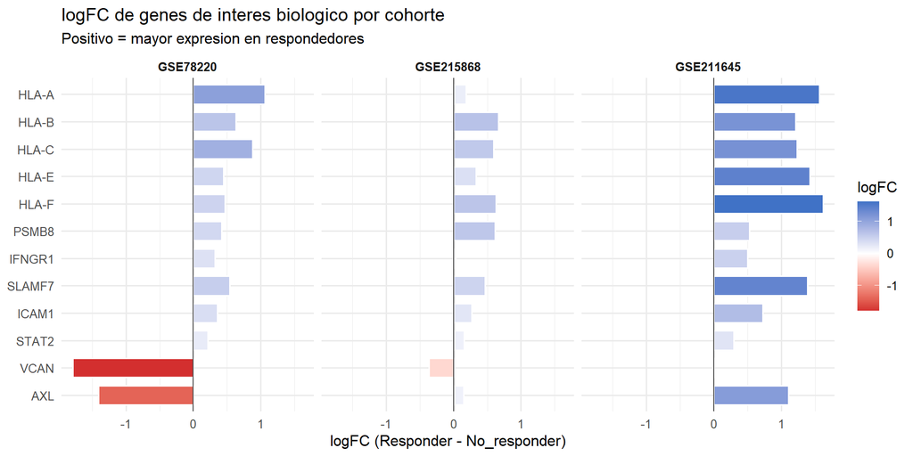

# 10 Guardado de tablas

```
## Tablas guardadas en: C:/Users/sonia/Desktop/2_TFM_MELANOMA/resultados/summary
```

```
## [1] "biological_signature_key_genes.csv"
## [2] "blood_sensitivity_summary.csv"
## [3] "cohort_overview.csv"
## [4] "concordant_genes_3cohorts.csv"
## [5] "executive_summary.csv"
## [6] "external_validation_gse91061_summary.csv"
## [7] "integrated_concordance_summary.csv"
## [8] "validation_summary.csv"
```

# 11 Resumen ejecutivo para revision

Resumen ejecutivo: resultados principales por bloque

| Bloque | Resultado clave |
| --- | --- |
| Descubrimiento GSE78220 (n=25) | 539 genes nominalmente sig. (P<0.05, &#124;logFC&#124;>=0.5); 0 FDR (esperado con n=25); LOOCV AUC=0.853 (top 5 genes) |
| Enriquecimiento funcional GSE78220 | 435 terminos GO BP exploratorios asociados a genes nominales; interpretar como apoyo biologico, no como resultado confirmatorio |
| Validacion GSE215868 anti-PD-1 (n=105) | 6/50 genes discovery presentes en panel; 66.7% misma direccion; AUC firma=0.547 |
| Validacion GSE211645 anti-CTLA-4 (n=40) | 1/50 genes discovery en panel; 0% misma direccion; AUC firma=0.39; limitacion: panel NanoString diferente |
| Validacion tumoral RNA-seq GSE91061 | AUC firma tumoral en GSE91061=0.474; interpretacion exploratoria como cohorte tumoral RNA-seq independiente |
| Sensibilidad sangre GSE94873 | AUC firma tumoral en sangre=0.475. Senal debil esperada por cambio de tejido, checkpoint y plataforma |
| Consistencia multi-cohorte (200 genes) | 69/200 genes concordantes en las 3 cohortes (61 Up, 8 Down); firma IFN-gamma/MHC-I (HLA-A/B/C/E/F, PSMB8, IFNGR1) consistentemente Up en respondedores en las 3 cohortes |

# 12 Conclusiones metodologicas

# 13 Informacion de sesion